```python
import pandas as pd
import numpy as np

import matplotlib.pyplot as plt
import re
import string
import os
import nltk
from nltk.tokenize import sent_tokenize
from nltk.corpus import words
from nltk.corpus import stopwords
from nltk.tokenize import word_tokenize
from nltk.stem import PorterStemmer
from nltk.sentiment.vader import SentimentIntensityAnalyzer
from nltk.sentiment.util import *
from sklearn.feature_extraction.text import CountVectorizer
from sklearn.decomposition import LatentDirichletAllocation
from collections import Counter
from nltk.collocations import *
from spellchecker import SpellChecker

from matplotlib import pyplot as plt
from matplotlib import ticker
import seaborn as sns
import plotly.express as px

import pyLDAvis
import pyLDAvis.sklearn

sns.set(style="darkgrid")
```

# PART ONE!

## 1.Cleaning and Normalizing the data

```python
df = pd.read_csv('Covid_19_tweets_train.csv', encoding='latin1')
df = df[['UserName','TweetAt','OriginalTweet','Location','Sentiment']]
df.sample(10)
```

|  | UserName | TweetAt | OriginalTweet | Location | Sentiment |
| --- | --- | --- | --- | --- | --- |
| 23455 | 27254 | 26-03-2020 | CONSUMER ALERT Scammers are offering COVID 19 ... | Spokane Washington USA | Positive |
| 13890 | 17689 | 21-03-2020 | When everyone buys responsibly then supermarke... | United Kingdom | Extremely Positive |
| 37838 | 41637 | 11/4/2020 | This is sweet potatoes. Yes, sweet potatoes. I... | Kampala, Uganda | Extremely Positive |
| 1932 | 5731 | 17-03-2020 | Time to start ripping everyone at the grocery ... | NaN | Neutral |
| 4584 | 8383 | 18-03-2020 | #Coronavirus in #NewZealand- Arrive in an inte... | NaN | Negative |
| 8973 | 12772 | 20-03-2020 | At least it s not war | London | Positive |
| 32273 | 36072 | 7/4/2020 | Heineken:5% Alcohol\r\r\n?Sanitizer:70% Alcoho... | Global | Neutral |
| 26968 | 30767 | 2/4/2020 | #Coronavirus Consumer advice: Answers to FAQs ... | Amersham | Neutral |
| 35360 | 39159 | 9/4/2020 | I work at a grocery store with constant contac... | Oregon | Positive |
| 31889 | 35688 | 7/4/2020 | Russia s gas in Europe in times of COVID 19 an... | Moscou - Paris - Forez | Positive |

### Cleaning Tweets as follow:

1. Remove URL.
2. Remove Punctuation marks.
3. Remove Stop words.
4. Remove Emojis and Photos.
5. Remove non-ASCII chars.
6. Convert to lowercase.
7. Apply Stemming.

```python
# Cleaning and normalizing the tweet texts
def tweet_cleaning(text):
    porter = PorterStemmer()
    remove_url = lambda x: re.sub(r'https:\S+','',str(x))
    remove_non_ascii = lambda x : re.sub('[^\x00-\x7F]+',' ', str(x))
    cvt_lower = lambda x: x.lower()
    remove_puncs = lambda x: x.translate(str.maketrans('','',r'''!()-[]{};:'"\,<>./?@$%^&*~'''))
    stop_words = set(stopwords.words('English'))
    remove_stop_word = lambda x: ' '.join([word for word in x.split() if word not in stop_words])
    remove_Emoji = lambda x : re.compile(pattern = "["
        u"\U0001F600-\U0001F64F"
        u"\U0001F300-\U0001F5FF"
        u"\U0001F680-\U0001F6FF"
        u"\U0001F1E0-\U0001F1FF"
                           "]+", flags = re.UNICODE).sub(r'',x)

    stemmed = [porter.stem(x) for x in text]
    return text.apply(remove_url).apply(cvt_lower).apply(remove_puncs).apply(remove_stop_word).apply(remove_Emoji).apply(remove_non_ascii)

# Cleaning the tweets (removing '#' and '_')
def split_tweets(text):
    remove_ = lambda x : re.sub('#','', str(x))
    remove = lambda x : re.sub('_',' ', str(x))
    return text.apply(remove_).apply(remove)
```

```python
df.OriginalTweet = tweet_cleaning(df['OriginalTweet'])
df.head()
```

|  | UserName | TweetAt | OriginalTweet | Location | Sentiment |
| --- | --- | --- | --- | --- | --- |
| 0 | 3799 | 16-03-2020 | menyrbie phil_gahan chrisitv | London | Neutral |
| 1 | 3800 | 16-03-2020 | advice talk neighbours family exchange phone n... | UK | Positive |
| 2 | 3801 | 16-03-2020 | coronavirus australia woolworths give elderly ... | Vagabonds | Positive |
| 3 | 3802 | 16-03-2020 | food stock one empty please dont panic enough ... | NaN | Positive |
| 4 | 3803 | 16-03-2020 | ready go supermarket #covid19 outbreak im para... | NaN | Extremely Negative |

```python
# pd.DataFrame({'Cleaned_Tweets': df.OriginalTweet}).to_csv('Cleaned_Tweets.csv', index=False)
```

## 2. Text Analysis

### 2.1- Find misspelled words

```python
#Finding the misspelled words and its frequencies...
spell = SpellChecker()
misspelled_words = []
hashtags_ = data_.hashtag.values.tolist()

for line in df.OriginalTweet:
    check_tweet= spell.unknown(line.split())
    for word in check_tweet:
        if word[0]!='#' and word not in hashtags_ and word not in ['covid','sanitizer','lockdown']:
            misspelled_words.append(word)

data = pd.DataFrame(list(compute_freq(misspelled_words,1).most_common(10)),
               columns =['word','frq'])
data.head()
```

|  | word | frq |
| --- | --- | --- |
| 0 | (youre,) | 276 |
| 1 | (realdonaldtrump,) | 249 |
| 2 | (website,) | 246 |
| 3 | (sanitizers,) | 236 |
| 4 | (cannot,) | 223 |

### 2.2- Find unusual words

```python
def unusual_words(text):
    text_vocab = set(w.lower() for w in text if w.isalpha())
    english_vocab = set(w.lower() for w in nltk.corpus.words.words())
    unusual = text_vocab - english_vocab
    return sorted(unusual)
```

### 2.3- Methods to find the n grams that have the most frequently...

#### 2.3.1- Using frequency distribution:

```python
# Find the n grams that have the most frequently...
def compute_freq(text, n):
   fdist = nltk.FreqDist()
   for line in text:
        if len(line) > 1:
            tokens = line.strip().split(' ')
            ngram = nltk.ngrams(tokens, n)
            fdist.update(ngram)
   return fdist
```

#### 2.3.1.1- Find most common uni, bi and tri -grams..

```python
# Most common uni,bi and tri grams..
uni = compute_freq(df.OriginalTweet,1)
bi = compute_freq(df.OriginalTweet,2)
tri = compute_freq(df.OriginalTweet,3)
data = pd.DataFrame(list(zip(uni.most_common(10), bi.most_common(10), tri.most_common(10))),
               columns =['Unigram', 'Bigram', 'Trigram'])
data.head()
```

|  | Unigram | Bigram | Trigram |
| --- | --- | --- | --- |
| 0 | ((#coronavirus,), 15893) | ((grocery, store), 4665) | ((grocery, store, workers), 425) |
| 1 | ((prices,), 7816) | ((covid, 19), 2768) | ((go, grocery, store), 282) |
| 2 | ((covid19,), 7602) | ((#coronavirus, #covid19), 1568) | ((grocery, store, employees), 232) |
| 3 | ((store,), 6761) | ((hand, sanitizer), 1487) | ((covid, 19, pandemic), 227) |
| 4 | ((food,), 6758) | ((#covid19, #coronavirus), 1389) | ((going, grocery, store), 202) |

#### 2.3.2- Using Collocations:

```python
bigram_measures = nltk.collocations.BigramAssocMeasures()
trigram_measures = nltk.collocations.TrigramAssocMeasures()
```

```python
def find_collocations(str_ : str):
    fdist = nltk.FreqDist()
    for line in df.OriginalTweet:
        tokens = nltk.wordpunct_tokenize(line)
        for word in tokens:
            if word == '#':
                tokens.remove(word)
        if str_ == 'bigrams':
            finder = BigramCollocationFinder.from_words(tokens)
            scored = finder.score_ngrams(bigram_measures.raw_freq)
            sorted(bigram for bigram, score in scored)
            sor = sorted(finder.nbest(bigram_measures.raw_freq, 2))
            fdist.update(sor)
        elif str_ == 'trigrams':
            finder = TrigramCollocationFinder.from_words(tokens)
            scored = finder.score_ngrams(trigram_measures.raw_freq)
            sorted(trigram for trigram, score in scored)
            sor = sorted(finder.nbest(trigram_measures.raw_freq, 2))
            fdist.update(sor)
        else:
            return None
    return fdist
```

#### 2.3.2.1- Find most common bi and tri -grams..

```python
bi = find_collocations('bigrams')
tri = find_collocations('trigrams')
data = pd.DataFrame(list(zip(bi.most_common(5),tri.most_common(5))),
               columns =['Bigram','Trigram'])
data.head()
```

|  | Bigram | Trigram |
| --- | --- | --- |
| 0 | ((coronavirus, covid19), 531) | ((amid, coronavirus, pandemic), 56) |
| 1 | ((grocery, store), 296) | ((amid, covid19, pandemic), 50) |
| 2 | ((covid, 19), 282) | ((amid, covid, 19), 48) |
| 3 | ((covid19, coronavirus), 271) | ((go, grocery, store), 43) |
| 4 | ((19, pandemic), 230) | ((grocery, store, workers), 39) |

##### 2.3.3 Find least common words

```python
# Least common words..
least = uni.most_common()[-30:]
least
```

```
[(('#bud',), 1),
 (('#fullsend',), 1),
 (('#nelkboys',), 1),
 (('#listentoyourheart',), 1),
 (('carifika',), 1),
 (('gampg',), 1),
 (('reservoirs',), 1),
 (('jaffri',), 1),
 (('#atcard',), 1),
 (('majangchien',), 1),
 (('#ecuadorunido',), 1),
 (('#savethechildren',), 1),
 (('#billgates#socialdistance',), 1),
 (('#radiation',), 1),
 (('_sunrise_sv',), 1),
 (('gamzap',), 1),
 (('bullions',), 1),
 (('#safehaven',), 1),
 (('171525ounce',), 1),
 (('172220',), 1),
 (('rs46215',), 1),
 (('gms',), 1),
 (('mrsilverscott',), 1),
 (('rejecting',), 1),
 (('kameronwilds',), 1),
 (('martinsville',), 1),
 (('tartiicat',), 1),
 (('newused',), 1),
 (('rift',), 1),
 (('whethe',), 1)]
```

## 3. Trending Topics

#### 3.1- Find most commom hashtags in Tweets using as follow:

1. Use the regular expression to find all the words that start with # simpol.
2. Calculate the frequency distribution for it.
3. return a list of trending hashtags.

```python
# Find most common hashtags fucn..
def trending():
    fdist = nltk.FreqDist()
    ls = []
    for line in df.OriginalTweet:
        res = re.findall(r'#(\w+)', line)
        if res != []:
            ls.append(res)
    for l in ls:
        fdist.update(l)
    return fdist
```

```python
# Find most common hashtags..
data_ = pd.DataFrame(list(trending().most_common(5)),
               columns =['hashtag','countt'])
data_.head()
```

|  | hashtag | countt |
| --- | --- | --- |
| 0 | coronavirus | 15973 |
| 1 | covid19 | 6062 |
| 2 | covid_19 | 3172 |
| 3 | covid2019 | 1672 |
| 4 | toiletpaper | 1615 |

#### 3.1.1- Visualize statistics for most used hashtags

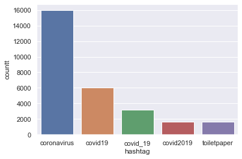

```python
sns.barplot(x = data_.hashtag, y = data_.countt)
```

#### 3.2- Visualize statistics for locations with the most Tweets

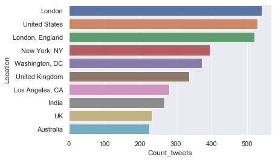

```python
count_df = df['Location'].value_counts().reset_index()
country_stats = count_df.head(10)
country_stats.columns = ['Location','Count_tweets']
sns.barplot(y = country_stats.Location, x = country_stats.Count_tweets, data=count_df)
```

## 4.Topic Modeling

#### 4.1- 'sklearn' used to achieve topic modeling as follows:

1. Create vocabulary matrix of all the words in my tweets data.
2. Create topics along with the probability distribution for each word in my vocabulary for each topic.
3. Apply an interactive web-based visualization.

#### 4.2- A simple explanation:

I used Latent Dirichlet Allocation with online variational Bayes algorithm (LDA) to automatically classify documents and estimate their relevance to various topics, after converting the text the tweets to a matrix of token counts.

```python
vectorizer = CountVectorizer(analyzer='word',min_df=3,stop_words='english',lowercase=True,token_pattern='[a-zA-Z0-9]{3,}',max_features=5000,)
data_matrix = vectorizer.fit_transform(df.OriginalTweet)
```

```python
lda_model = LatentDirichletAllocation(n_components=10,learning_method='online',random_state=20,n_jobs = -1)
lda_output = lda_model.fit_transform(data_matrix)
```

```python
pyLDAvis.enable_notebook()
pyLDAvis.sklearn.prepare(lda_model, data_matrix, vectorizer, mds='tsne')
```

[interactive chart not shown]

# PART TWO!

```python
from nltk.tokenize.treebank import TreebankWordDetokenizer
from nltk.lm import MLE
from nltk import word_tokenize

import tensorflow as tf
from tensorflow import keras
from tensorflow.keras import layers
from tensorflow.keras.models import Sequential, Model
from tensorflow.keras.preprocessing.text import one_hot, Tokenizer
from tensorflow.keras.preprocessing.sequence import pad_sequences
from tensorflow.keras.layers import Dense, Flatten, Embedding, Input, LSTM, Conv1D, MaxPool1D, Bidirectional, SpatialDropout1D, Dropout, GlobalMaxPooling1D, Activation

from sklearn.model_selection import train_test_split
from sklearn.feature_extraction.text import TfidfVectorizer, CountVectorizer
from sklearn.svm import LinearSVC
from sklearn.linear_model import LogisticRegression
import plotly.graph_objects as go
```

## 5. Language Models

### 5.1- Generate new tweets

- Create a language model using MLE and Train it on n-gram.
- Use **generate_tweet** function to get the new tweet.

```python
def tokenize_words(text):
    return list(text.apply(word_tokenize))

def generate_tweet(model, length):
    tweet = []
    for token in model.generate(length, random_seed = 50):
        if token == '</s>':
            break
        tweet.append(token)
    return  TreebankWordDetokenizer().detokenize(tweet)
```

```python
def train_language_model(n, data):
    tokenized_tweets = tokenize_words(data)
    train , vocabs = nltk.lm.preprocessing.padded_everygram_pipeline(n, tokenized_tweets)
    model = MLE(n)
    model.fit(train,vocabs)
    return model
```

```python
covid19_model = train_language_model(3,df.OriginalTweet)
```

```python
generate_tweet(covid19_model, 22)
```

```
'can do their grocery stocked Especially the elderly in Nashville . https: //t.co/JfDMYk5b8e'
```

## 6- Sentiment Analysis

### 6.1- Classifiers

6.1.1- **Linear Support Vector Classification** it is more flexibility in scaling large numbers of samples and extremely fast in practice.

```python
from sklearn import svm
def train_classifier_svm(train_data, train_labels, test_data, test_labels):
    clf = svm.NuSVC(gamma = 'auto')
    clf.fit(train_data, train_labels)
    return clf.predict(test_data), clf.score(test_data,test_labels)
```

```python
def train_classifier(train_data, train_labels, test_data, test_labels):
    clf = LinearSVC(random_state=0, tol=1e-5)
    clf.fit(train_data, train_labels)
    return clf.predict(test_data), clf.score(test_data,test_labels)
```

6.1.2- **Logistic Regression Classification**

```python
def train_linear_classifier(train_data, train_labels, test_data, test_labels):
    clf = LogisticRegression(C=30.0, class_weight='balanced', solver='newton-cg', multi_class='multinomial', n_jobs=-1, random_state=40,verbose = True)
    clf.fit(train_data, train_labels)
    #y_predicted_counts = clf.predict(test_data)
    return clf.score(test_data,test_labels)
```

```python
from sklearn.multiclass import OneVsRestClassifier
from sklearn.linear_model import RidgeClassifier
def train_ridge_classifier(train_data, train_labels, test_data, test_labels):
    clf = RidgeClassifier()
    clf.fit(train_data, train_labels)
    return clf.predict(test_data), clf.score(test_data,test_labels)
```

### Visualization Function

```python
def plot_bar(y_pred, y_test):
    cleard_res = np.where(y_pred == y_test, y_pred ,'null')
    coun = []
    for i in cleard_res:
        if i != 'null':
            coun.append(1)
        else:
            coun.append(0)

    d = {'pred': y_pred, 'test': y_test, 'label': coun}
    clsf = pd.DataFrame(data=d)

    data_agg = clsf[['pred','test','label']].groupby(['test','label']).count().reset_index()
    data_agg.columns = ['pred','label','count']

    right_pred = np.where(data_agg['label'] == 1, data_agg['pred'] ,'null')
    wrong_pred = np.where(data_agg['label'] == 0, data_agg['pred'] ,'null')
    right_pred = list(right_pred)
    wrong_pred = list(wrong_pred)

    right_pred_counts = np.where(data_agg['label'] == 1, data_agg['count'] ,'null')
    wrong_pred_counts = np.where(data_agg['label'] == 0, data_agg['count'] ,'null')
    right_pred_counts = list(right_pred_counts)
    wrong_pred_counts = list(wrong_pred_counts)


    for i in right_pred:
        if i == 'null':
            right_pred.remove('null')
    for i in wrong_pred:
        if i == 'null':
            wrong_pred.remove(i)

    for i in right_pred_counts:
        if i == 'null':
            right_pred_counts.remove('null')
    for i in wrong_pred_counts:
        if i == 'null':
            wrong_pred_counts.remove(i)
    fig = go.Figure(data=[
        go.Bar(name='right_prediction', y=right_pred_counts, x= right_pred),
        go.Bar(name='wrong_prediction', y=wrong_pred_counts, x= wrong_pred)
    ])
    fig.update_layout(barmode='group')
    fig.show()
```

### 6.2- Text Classification and Sentiment Analysis

#### Data preparation

```python
# Split the dataset into random train and test subsets
df.OriginalTweet = split_tweets(df.OriginalTweet)
X_train, X_test, y_train, y_test = train_test_split(df.OriginalTweet, df.Sentiment, test_size=.25, random_state=42)
```

### 6.2.2- TF-IDF

```python
def fit_corpus(train_data, test_data):
    corpus = pd.DataFrame({"Tweet": train_data})
    tfidf = TfidfVectorizer(min_df=2, max_df=0.5, ngram_range=(1,2))
    tfidf.fit(corpus["Tweet"])
    return tfidf
```

```python
def transform_data(tfidf, data):
    features = tfidf.transform(data)
    return pd.DataFrame(features.todense(), columns = tfidf.get_feature_names())
```

```python
tfidf = fit_corpus(X_train,X_test)
train_features = transform_data(tfidf, X_train)
test_features = transform_data(tfidf, X_test)
```

```python
# multi-class classification..
y_pred, accuracy = train_classifier(train_features, y_train, test_features, y_test)
print('Accuracy: {:0.3f}'.format(accuracy))
```

```
Accuracy: 0.539
```

```python
plot_bar(y_pred, y_test)
```

[interactive chart not shown]

### 6.2.3- Bag of words (BOW)

```python
def cv(data):
    count_vectorizer = CountVectorizer()
    emb = count_vectorizer.fit_transform(data)
    return emb, count_vectorizer
```

```python
train_counts, count_vectorizer = cv(X_train)
test_counts = count_vectorizer.transform(X_test)
```

```python
# multi-class classification..
y_pred, accuracy = train_classifier_svm(train_counts, y_train, test_counts, y_test)
print('Accuracy: {:0.3f}'.format(accuracy))
```

```
Accuracy: 0.603
```

```python
plot_bar(y_pred, y_test)
```

[interactive chart not shown]

### 6.2.4- Deep Neural Networks

#### Data preparation

Split the dataset into random train and test subsets, Converting the data to **numerical data**.

```python
df.OriginalTweet = split_tweets(df.OriginalTweet)
```

```python
list_of_words = []
for i in df.OriginalTweet:
    for j in i.split():
        list_of_words.append(j)
total_words = len(list(set(list_of_words)))
total_words
```

```
60242
```

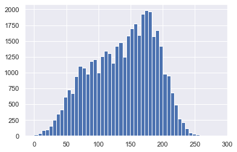

```python
# a histogram to show the maximum length of the tweets.
plt.hist([len(s) for s in df.OriginalTweetiginalTweet], bins = 50)
plt.show()
```

```python
tokenizer = Tokenizer(num_words=total_words)
tokenizer.fit_on_texts(df['OriginalTweet'].values)
X = tokenizer.texts_to_sequences(df['OriginalTweet'].values)
X = pad_sequences(X, maxlen=40)
Y = pd.get_dummies(df['Sentiment']).values

print('Shape of training data:', X.shape)
print('Shape of labeling data:', Y.shape)
```

```
Shape of training data: (41157, 40)
Shape of labeling data: (41157, 5)
```

```python
X_train, X_test, Y_train, Y_test = train_test_split(X, Y, test_size=.10, random_state=42)
```

#### Visualization

```python
def plot_history(history):
    acc = history.history['acc']
    val_acc = history.history['val_acc']
    loss = history.history['loss']
    val_loss = history.history['val_loss']
    x = range(1, len(acc) + 1)

    plt.figure(figsize=(12, 5))
    plt.subplot(1, 2, 1)
    plt.plot(x, acc, 'b', label='Training acc')
    plt.plot(x, val_acc, 'r', label='Validation acc')
    plt.title('Training and validation accuracy')
    plt.legend()
    plt.subplot(1, 2, 2)
    plt.plot(x, loss, 'b', label='Training loss')
    plt.plot(x, val_loss, 'r', label='Validation loss')
    plt.title('Training and validation loss')
    plt.legend()
```

### 6.2.4.1- **CNN**

```python
model = Sequential()

model.add(Embedding(total_words, output_dim = 128))
model.add(Dropout(0.2))
model.add(layers.Conv1D(128, 5,  padding='valid',activation='relu',strides=1))

model.add(GlobalMaxPooling1D())

model.add(Dense(10))
model.add(Dropout(0.2))
model.add(Activation('relu'))


model.add(Dense(5))
model.add(Activation('softmax'))

model.compile(loss='categorical_crossentropy', optimizer='adam', metrics=['accuracy'])
model.summary()
```

[output not shown]

```
Model: "sequential"
_________________________________________________________________
Layer (type)                 Output Shape              Param #
=================================================================
embedding (Embedding)        (None, None, 128)         7710976
_________________________________________________________________
dropout (Dropout)            (None, None, 128)         0
_________________________________________________________________
conv1d (Conv1D)              (None, None, 128)         82048
_________________________________________________________________
global_max_pooling1d (Global (None, 128)               0
_________________________________________________________________
dense (Dense)                (None, 10)                1290
_________________________________________________________________
dropout_1 (Dropout)          (None, 10)                0
_________________________________________________________________
activation (Activation)      (None, 10)                0
_________________________________________________________________
dense_1 (Dense)              (None, 5)                 55
_________________________________________________________________
activation_1 (Activation)    (None, 5)                 0
=================================================================
Total params: 7,794,369
Trainable params: 7,794,369
Non-trainable params: 0
_________________________________________________________________
```

```python
cnn_history = model.fit(X_train, Y_train ,batch_size=64, epochs = 3, validation_split = 0.1)
```

```
Train on 33336 samples, validate on 3705 samples
```

```python
accr = model.evaluate(X_test,Y_test)
print('Accuracy: {:0.3f}'.format(accr[1]))
```

```
Accuracy: 0.686
```

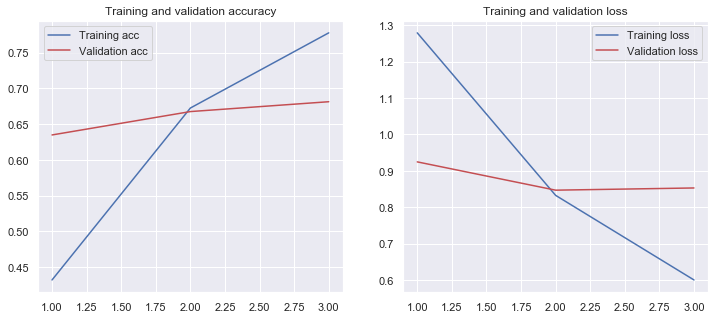

```python
plot_history(cnn_history)
```

### 6.2.4.2- **LSTM**

```python
model = Sequential()
model.add(Embedding(total_words, 100, input_length=X.shape[1]))
model.add(SpatialDropout1D(0.2))
model.add(LSTM(100, dropout=0.2, recurrent_dropout=0.2))
model.add(Dense(5, activation='softmax'))
model.compile(loss='categorical_crossentropy', optimizer='adam', metrics=['accuracy'])
print(model.summary())
```

```
Model: "sequential_2"
_________________________________________________________________
Layer (type)                 Output Shape              Param #
=================================================================
embedding_2 (Embedding)      (None, 40, 100)           6024200
_________________________________________________________________
spatial_dropout1d_1 (Spatial (None, 40, 100)           0
_________________________________________________________________
lstm_1 (LSTM)                (None, 100)               80400
_________________________________________________________________
dense_3 (Dense)              (None, 5)                 505
=================================================================
Total params: 6,105,105
Trainable params: 6,105,105
Non-trainable params: 0
_________________________________________________________________
None
```

```python
from keras.callbacks import EarlyStopping
lstm_history = model.fit(X_train, Y_train, epochs = 2, batch_size = 64, validation_split = 0.1,
          callbacks=[EarlyStopping(monitor='val_loss', patience=3, min_delta=0.0001)])
```

```
Train on 33336 samples, validate on 3705 samples
```

```python
accr = model.evaluate(X_test,Y_test)
print('Accuracy: {:0.3f}'.format(accr[1]))
```

```
Accuracy: 0.727
```

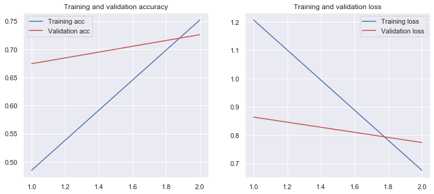

```python
plot_history(lstm_history)
```

### 6.2.4.3- **BI-LSTM**

```python
# Sequential Model

model = Sequential()

model.add(Embedding(total_words, output_dim = 128))
model.add(Bidirectional(LSTM(128)))
model.add(Dense(5,activation= 'softmax'))

model.compile(optimizer='adam', loss='categorical_crossentropy', metrics=['acc'])
model.summary()
```

[output not shown]

```python
bi_lstm_history = model.fit(X_train, Y_train, batch_size = 64, validation_split = 0.1, epochs = 2)
```

```
Train on 33336 samples, validate on 3705 samples
```

```python
accr = model.evaluate(X_test,Y_test)
print('Accuracy: {:0.3f}'.format(accr[1]))
```

```
Accuracy: 0.730
```

```python
model_ = tf.keras.models.load_model('bi-lstm.h5')
accr = model_.evaluate(X_test,Y_test)
print('Accuracy: {:0.3f}'.format(accr[1]))
```

```
Accuracy: 0.738
```

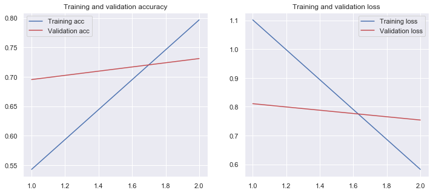

```python
plot_history(bi_lstm_history)
```

```python
# model.save('bi-lstm.h5')
```

### 7.1- Converting the data into binary as follows:

- 1 for the positive tweet
- 0 for the negative tweet
- remove the neutral tweet

```python
df.OriginalTweet = split_tweets(df.OriginalTweet)
```

```python
binary_labels = []
for label in df.Sentiment:
    if label == 'Extremely Negative'or label == 'Negative':
        binary_labels.append('0')
    elif label == 'Extremely Positive'or label == 'Positive':
        binary_labels.append('1')
len(binary_labels)
```

```
33444
```

```python
binary_tweets = np.where(df['Sentiment']!= 'Neutral', df.OriginalTweet,'null')
binary = []
for i in binary_tweets:
    if i != 'null':
        binary.append(i)
len(binary)
new_data = pd.DataFrame(binary, columns=['tweet'])
new_data['label'] = binary_labels
```

```python
pd.DataFrame({'tweet': new_data.tweet,'label' : new_data.label}).to_csv('binary_data.csv', index=False)
new_data.head()
```

|  | tweet | label |
| --- | --- | --- |
| 0 | advice talk neighbours family exchange phone n... | 1 |
| 1 | coronavirus australia woolworths give elderly ... | 1 |
| 2 | food stock one empty please dont panic enough ... | 1 |
| 3 | ready go supermarket covid19 outbreak im paran... | 0 |
| 4 | news region s first confirmed covid19 case cam... | 1 |

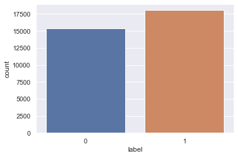

```python
df_binary = new_data[['tweet','label']].groupby(['label']).count().reset_index()
df_binary.columns = ['label','count']
sns.barplot(x = 'label', y = 'count', data=df_binary)
```

```python
list_of_words_ = []
for i in new_data.tweet:
    for j in i.split():
        list_of_words_.append(j)
total_words = len(list(set(list_of_words_)))
total_words
```

```
52733
```

```python
X_train, X_test, y_train, y_test = train_test_split(new_data.tweet, new_data.label, test_size=.20, random_state=42)
```

```python
# Create a tokenizer to tokenize the words and create sequences of tokenized words
tokenizer = Tokenizer(num_words = total_words)
tokenizer.fit_on_texts(X_train)
train_sequences = tokenizer.texts_to_sequences(X_train)
test_sequences = tokenizer.texts_to_sequences(X_test)
```

```python
padded_train = pad_sequences(train_sequences,maxlen = 32, padding = 'post', truncating = 'post')
padded_test = pad_sequences(test_sequences,maxlen = 32, truncating = 'post')
```

```python
for i,doc in enumerate(padded_train[:2]):
     print("The padded encoding for tweet",i+1," is : ",doc)
```

```
The padded encoding for tweet 1  is :  [  35  232 1165 2947  468   16    4   61  732  180  969   84  205 2452
  818  880   17   36    8    5 1024 7881    0    0    0    0    0    0
    0    0    0    0]
The padded encoding for tweet 2  is :  [   31   449  8934 18424  2608  7882    26    24   480    33   168    27
     2     1    80 10468 13030     0     0     0     0     0     0     0
     0     0     0     0     0     0     0     0]
```

```python
model = Sequential()

model.add(Embedding(total_words, output_dim = 128))
model.add(Bidirectional(LSTM(128)))
model.add(Dense(128, activation = 'relu'))
model.add(Dense(1,activation= 'sigmoid'))
model.compile(optimizer='adam', loss='binary_crossentropy', metrics=['acc'])

model.summary()
```

```
Model: "sequential_3"
_________________________________________________________________
Layer (type)                 Output Shape              Param #
=================================================================
embedding_3 (Embedding)      (None, None, 128)         6749824
_________________________________________________________________
bidirectional_3 (Bidirection (None, 256)               263168
_________________________________________________________________
dense_6 (Dense)              (None, 128)               32896
_________________________________________________________________
dense_7 (Dense)              (None, 1)                 129
=================================================================
Total params: 7,046,017
Trainable params: 7,046,017
Non-trainable params: 0
_________________________________________________________________
```

```python
y_train = np.asarray(y_train)
model.fit(padded_train, y_train, batch_size = 64, validation_split = 0.1, epochs = 2)
```

```
Train on 24079 samples, validate on 2676 samples
```

```
<tensorflow.python.keras.callbacks.History at 0x2292d48cc48>
```

```python
np.asarray(y_train)
accr = model.evaluate(padded_test,np.asarray(y_test))

print('Accuracy: {:0.3f}'.format(accr[1]))
```

```
Accuracy: 0.830
```

```python
model.save('bi-lstm-binary.h5')
```

### 7.4- A Comparison between multi-class and binary classification using "BI-LSTM" model

| Classifier Type | Accuracy |
| --- | --- |
| multi-class | 73.8 |
| binary | 83.0 |

## 8- Testing Functions

### 8.1- Cleaning and Normalization test function

```python
def cleaning_result(text):
    text = pd.DataFrame(text,columns=['tweet'])
    result = tweet_cleaning(text['tweet'])
    return list(split_tweets(result))
```

```python
test_list = ['hello!! ?' , 'hi! I am using whatsapp.']
test_func = cleaning_result(test_list)
test_func
```

```
['hello', 'hi using whatsapp']
```

### 8.2- Test new data on the best model that has been trained (BI-LSTM)

```python
def testing_result(path: str):

    # reading and cleaning the data.
    test_df = pd.read_csv(path, encoding='latin1')
    result = tweet_cleaning(df['OriginalTweet'])
    test_df.OriginalTweet = split_tweets(result)
    test_df = test_df[['UserName','TweetAt','OriginalTweet','Location','Sentiment']]

    #convert the data into numerical data.
    X = tokenizer.texts_to_sequences(test_df['OriginalTweet'].values)
    X = pad_sequences(X, maxlen=100)
    Y = pd.get_dummies(test_df['Sentiment']).values

    #load the best model 'bi-lstm'
    model_clf = tf.keras.models.load_model('bi-lstm.h5')

    accr = model_clf.evaluate(X_test,Y_test)
    return ('Accuracy: {:0.3f}'.format(accr[1]))
```

```python
testing_result('Covid_19_tweets_train.csv')
```

[output not shown]

```
'Accuracy: 0.730'
```

## 9- Results (Conclusion and Comparison)

[output not shown]